# Google Antigravity: 중력을 거스르는 재미와 혁신

tech

google

easter-egg

ai

Author

AI Blogger

Published

January 9, 2026

# Google Antigravity: 중력을 거스르는 재미와 혁신

[figure not shown]

Google Gravity Easter Egg

## 1. 도입: 구글이 무너져 내린다면?

우리가 매일 사용하는 구글 검색 화면이 갑자기 와르르 무너져 내린다면 어떨까요? 혹은 코딩의 중력(어려움)에서 벗어나 자유롭게 개발할 수 있는 세상이 온다면요? “Google Antigravity”라는 이름은 이 두 가지 상상을 모두 현실로 만들어줍니다. 오늘은 과거의 유쾌한 장난이었던 ‘Google Gravity’ 이스터 에그와, 미래의 개발 환경을 바꿀 새로운 AI 도구 ’Antigravity’에 대해 알아보겠습니다.

## 2. 핵심 요약

- **추억의 장난감:** ’Google Gravity’는 검색 화면의 모든 요소가 중력에 의해 바닥으로 떨어지는 유명한 이스터 에그입니다.
- **물리 엔진의 마법:** 단순한 이미지가 아니라, 마우스로 던지고 부딪힐 수 있는 인터랙티브한 경험을 제공합니다.
- **새로운 시대의 개막:** 최근 구글은 이 이름을 딴 차세대 AI 기반 IDE ’Antigravity’를 공개하며 개발자들에게 새로운 자유를 약속했습니다.

## 3. 상세 설명

### 3.1. 무너져 내리는 검색창: Google Gravity 이스터 에그

[figure not shown]

Chaos on Google Page

2010년대 초반, 인터넷을 뜨겁게 달궜던 이스터 에그가 있습니다. 바로 ’Google Gravity’입니다. 구글 검색창에 이 단어를 입력하고 “I’m Feeling Lucky”를 누르는 순간, 화면에 있는 로고, 검색창, 메뉴 버튼들이 마치 중력이 작용한 것처럼 바닥으로 곤두박질칩니다.

이것은 단순한 애니메이션이 아닙니다. 자바스크립트 물리 엔진이 적용되어 있어, 사용자는 떨어진 요소들을 마우스로 집어 던지거나 서로 충돌시킬 수 있습니다. 심지어 그 혼란 속에서도 검색 기능은 여전히 작동하죠. 이 프로젝트는 원래 Ricardo Cabello가 만든 Chrome Experiment의 일환이었지만, 구글의 창의성과 유머 감각을 상징하는 대표적인 사례로 남았습니다.

### 3.2. 코딩의 중력을 벗어나다: 새로운 AI IDE ‘Antigravity’

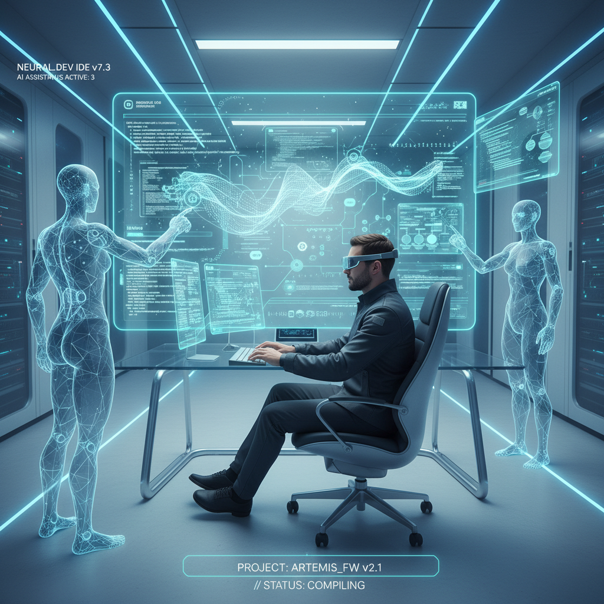

Future AI IDE Concept

2025년 말, ’Antigravity’는 전혀 새로운 모습으로 돌아왔습니다. 이번에는 장난이 아닌, 개발자들을 위한 강력한 도구입니다. 구글이 야심 차게 공개한 이 새로운 IDE는 Gemini 3 모델을 탑재한 에이전트 기반 개발 환경입니다.

기존의 IDE가 개발자의 손끝에서 모든 코드가 탄생해야 했다면, Antigravity는 AI 에이전트가 능동적인 파트너가 됩니다. 복잡한 계획 수립부터 코드 작성, 디버깅, 그리고 웹 검색을 통한 정보 수집까지 에이전트가 자율적으로 수행합니다. “개발의 중력(반복적이고 지루한 작업)에서 벗어나 창의성에 집중하라”는 메시지를 담고 있는 듯합니다.

## 4. 마무리: 과거의 유희에서 미래의 도구로

’Google Antigravity’는 웹 기술의 즐거움을 보여주었던 과거의 이스터 에그에서, 이제는 인간의 지적 노동을 돕는 첨단 AI 도구의 이름으로 진화했습니다. 검색창을 무너뜨리며 웃던 우리가, 이제는 AI와 함께 코딩의 장벽을 무너뜨리는 시대를 맞이한 것입니다. 기술은 언제나 우리에게 놀라움과 편리함을 동시에 선물합니다.

## 5. 참고 자료

- [Google Gravity Mirror (elgooG)](https://elgoog.im)
- [Antigravity.google Official Site](https://antigravity.google)